# DPP Survey 2022 Data

Beers

2023-05-08

# Thank you (And Disclaimers)

Welcome, one and all, to the slightly overdue results of the 2022 DPP Survey! We had over 2,000 responses, and we cannot thank you all enough for your participation and your thoughts. The survey is a critical tool for us to evaluate the health of the subreddit, get user input on all sorts of aspects of the DPP experience, and learn more about the demographics of our community.

First, though, it’s worth noting that while we tried our best to get the largest sample possible, that does not necessarily mean that we got a completely representative sample. Without information on whether users of certain demographics are more likely to respond to the survey, we cannot adequately control for response bias. That’s an unfortunate but unavoidable limitation. It’s also worth pointing out that the question listed above the legend for each of these plots is often a paraphrased version of the actual survey question - some of those questions were long, and it was necessary to shorten them for space reasons. Finally, we want to emphasize that the presentation of these summary statistics and plots is not intended to convey any specific connotations about the opinions of the mods - it is strictly intended to present the data we gathered in an interpretable and sensible way.

Come with us, and we’ll show you the data!

# Summary Demographics

First off, let’s look at some basic demographic information about the DPP population.

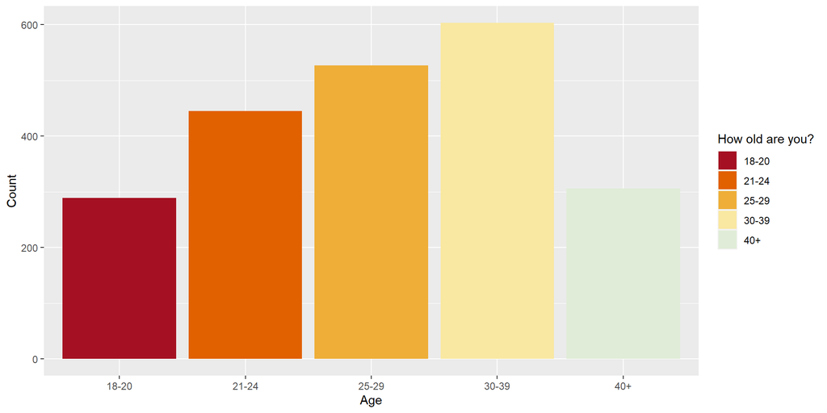

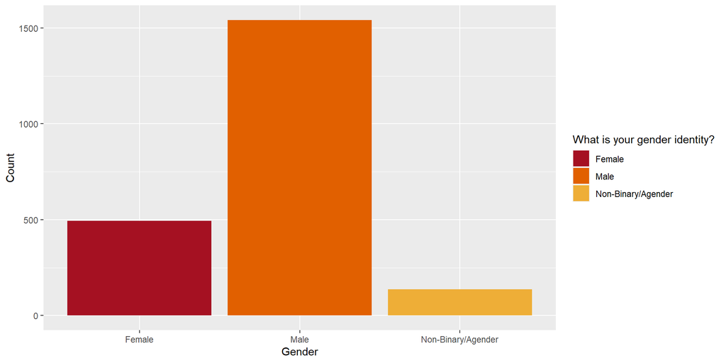

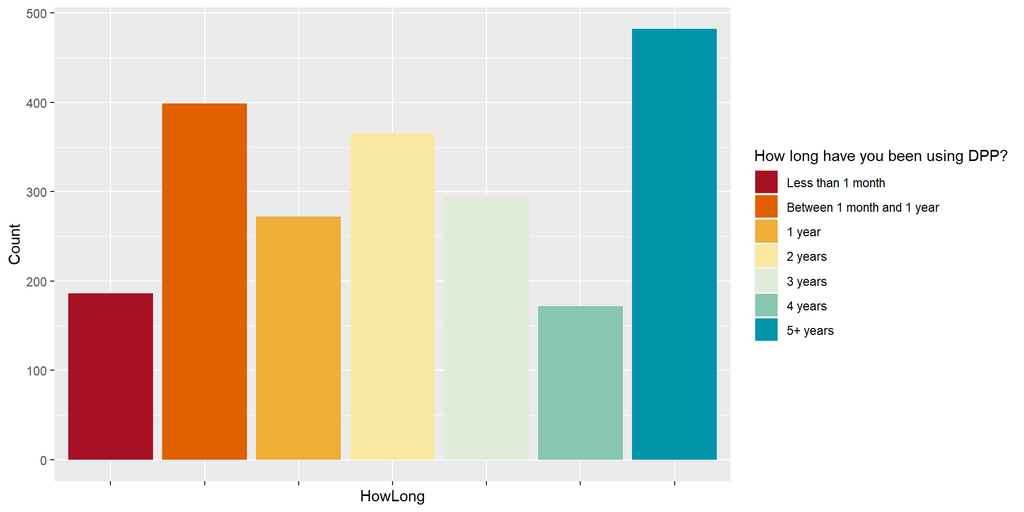

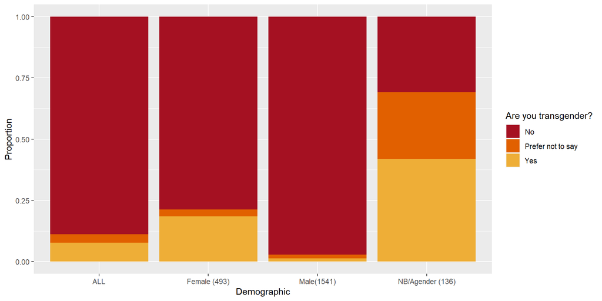

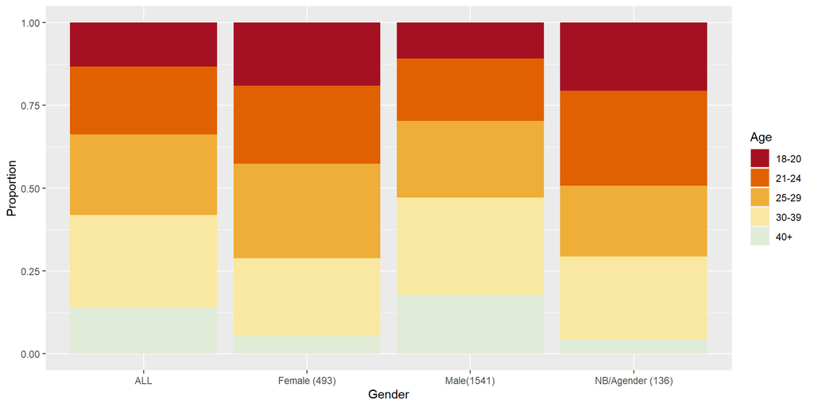

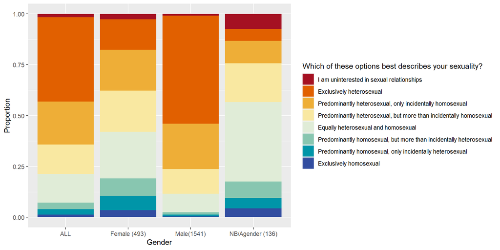

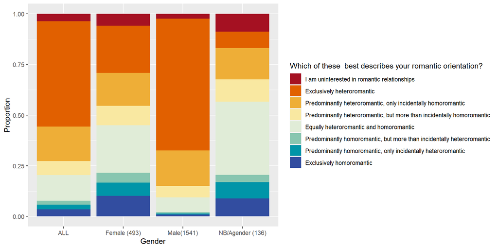

# Opinion data

Now we’re past the demographic statistics; the following plots examine how DPP users interact with the sub, and how they feel about a few issues that might affect their use of DPP.

First, do our users feel that it’s important for their partner’s gender to match the gender they’re posting as?

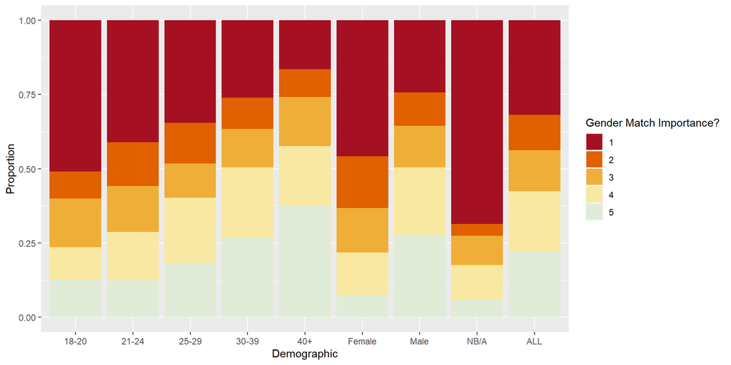

Next, how many users are looking for roleplay, conversation, or both?

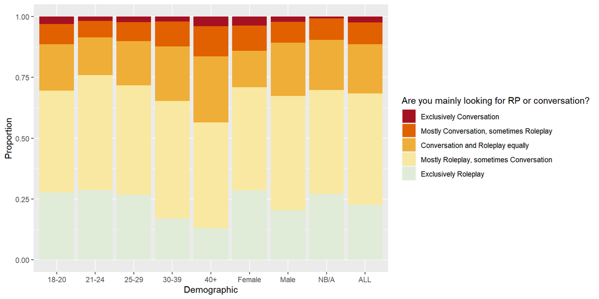

More of a matter of curiosity to us, but what do our users mean when they talk about a ‘long-term’ interaction?

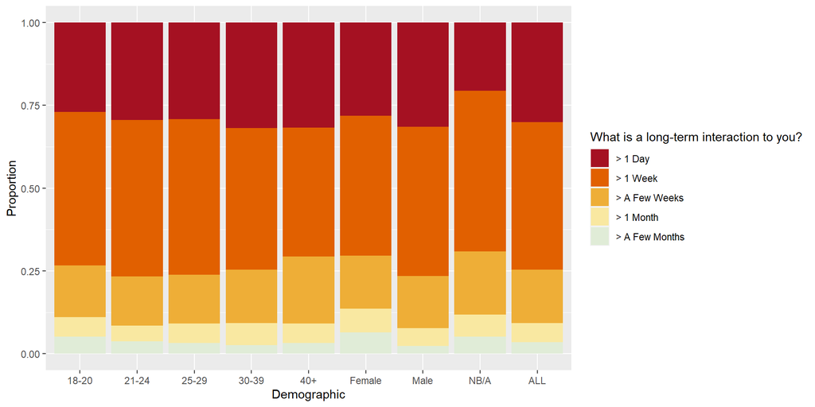

And finally, how many partners do our users want to juggle at once? No wrong answers, as always.

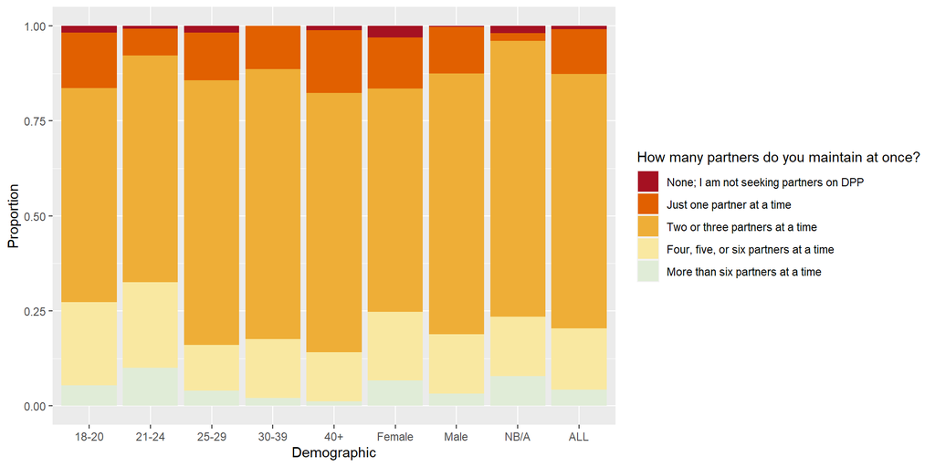

Next, we have some questions about ghosting, and here we want to emphasize once more that we don’t take any particular stances here; we want the data to speak for itself.

What proportion of our users have ever ghosted a partner, or been ghosted themselves?

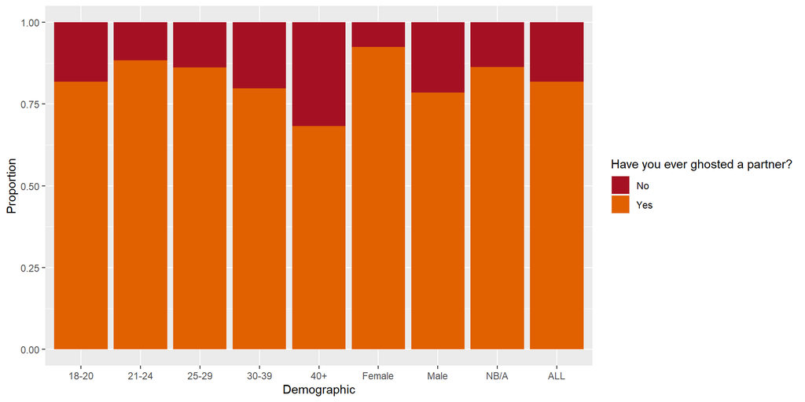

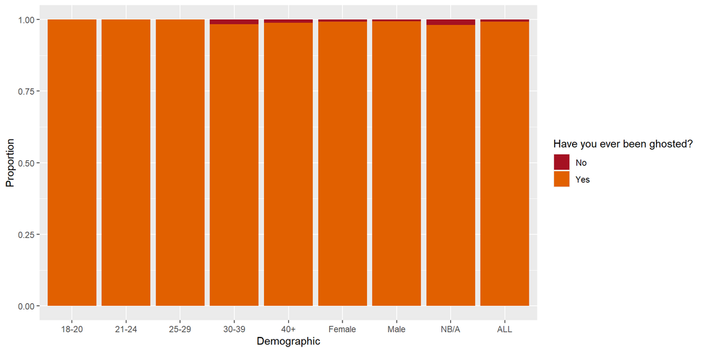

Next, how do our users feel about this? How much do they care about not ghosting and not being ghosted? And do they feel that ghosting can ever be justified?

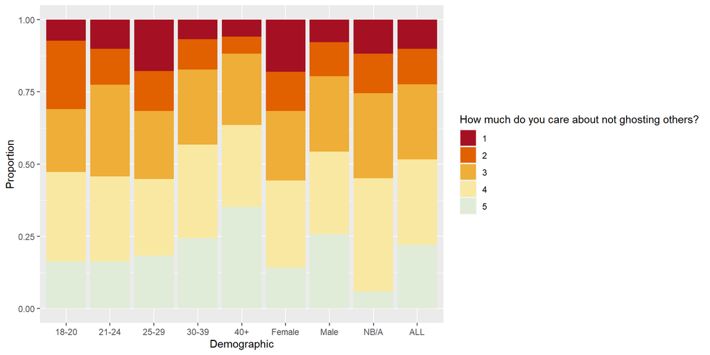

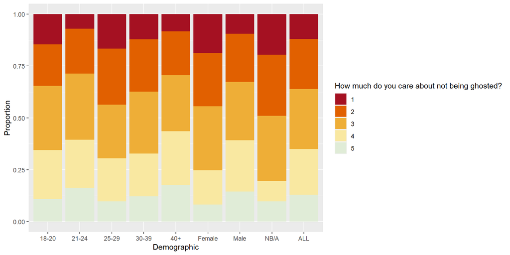

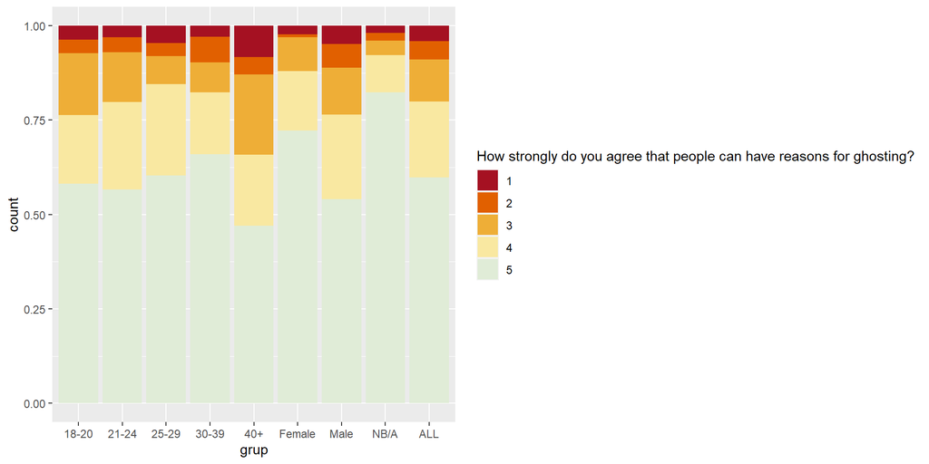

# Posting

These next few questions all had to do with the way DPP users post. First, the precondition for everything else - *did* they post in 2022?

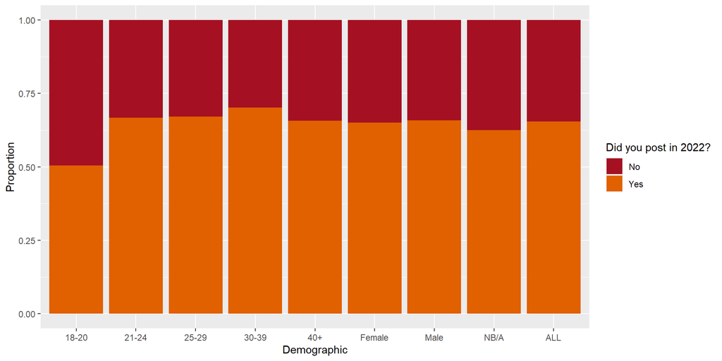

If so, how often?

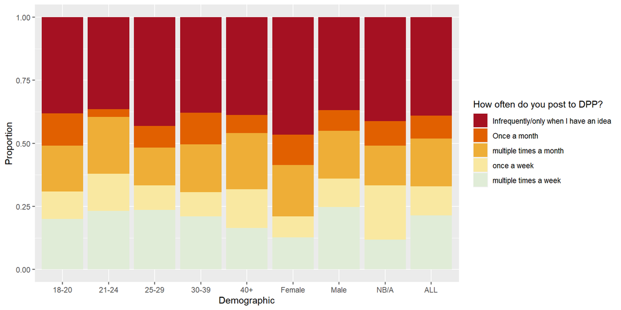

Did they post for chat?

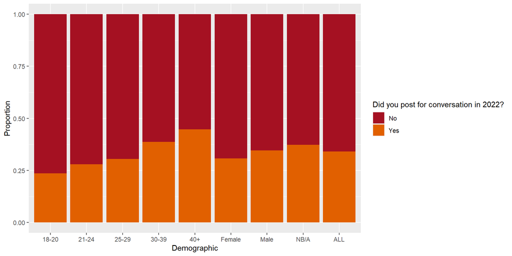

And/or for roleplay?

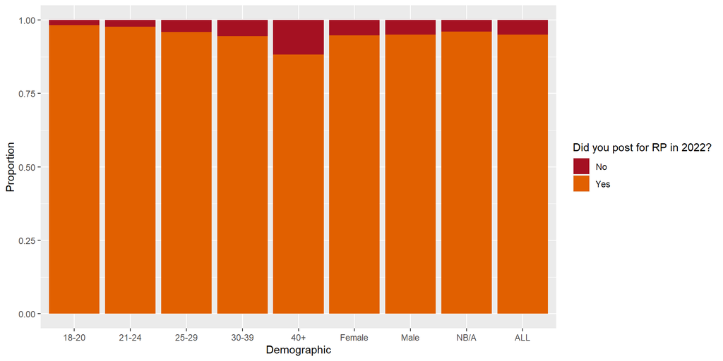

Did they get replies?

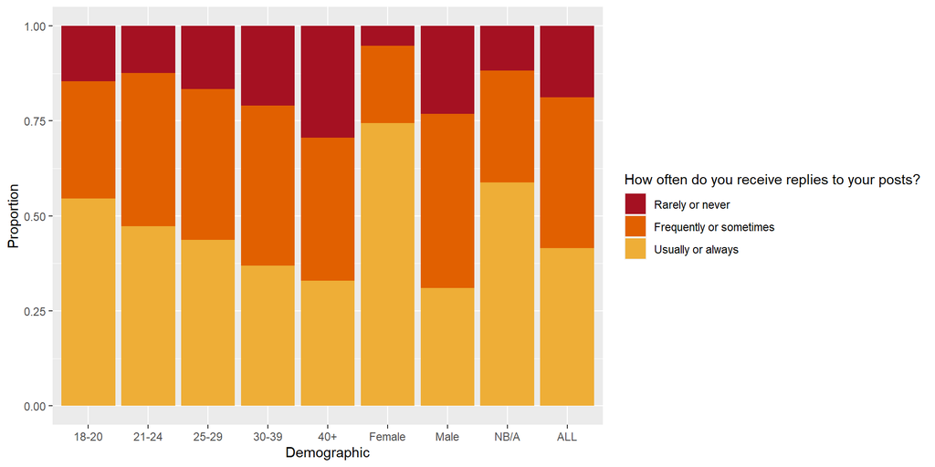

And how often did things end well, with a sustained interaction?

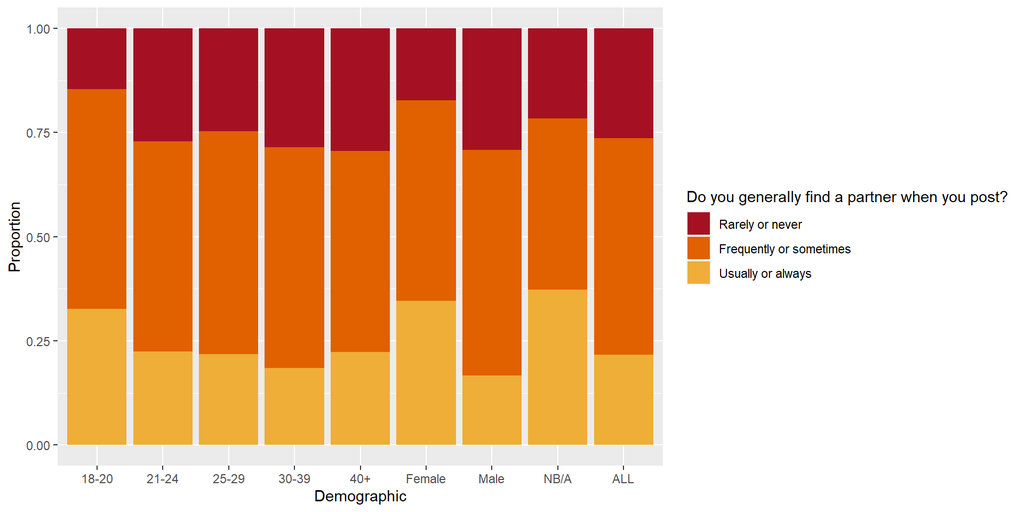

Which genders did they post as - their own, others, or perhaps both?

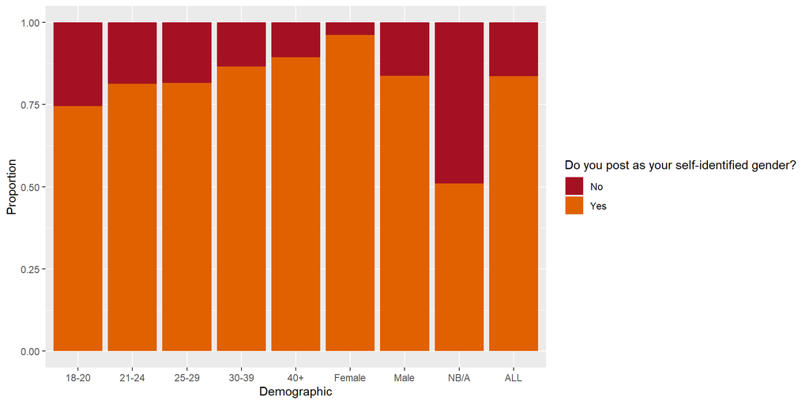

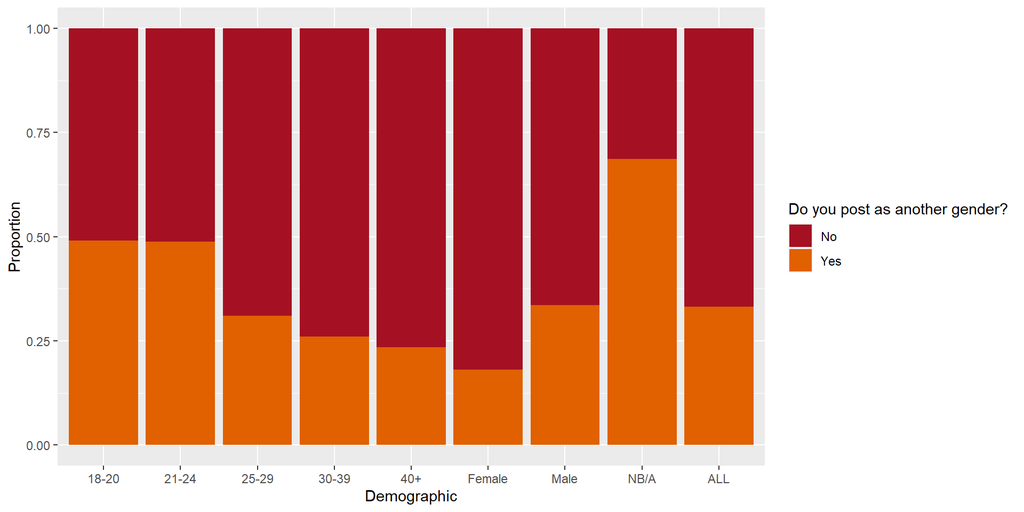

Did they post in search of partners of the same gender, another gender, or both?

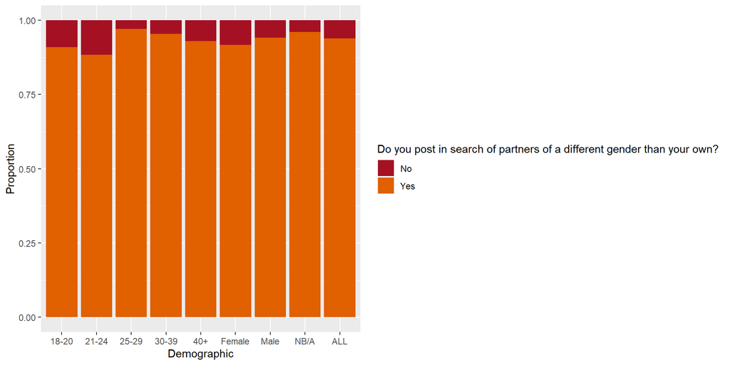

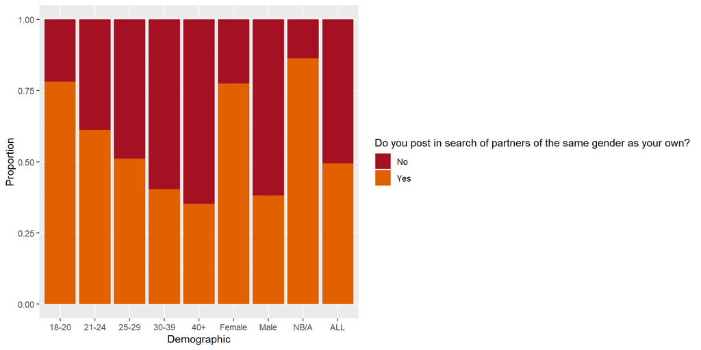

We all know and/or love novelty tags, but who’s actually using them?

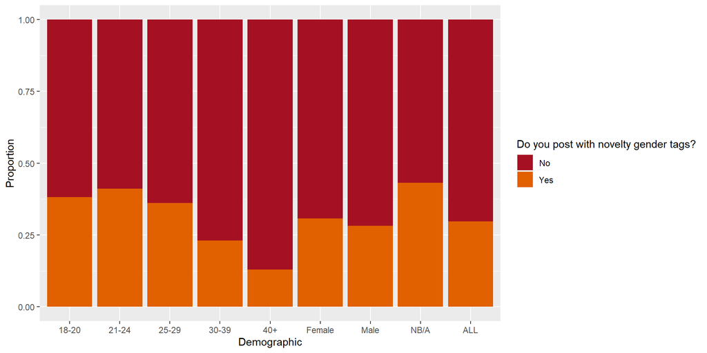